# Reproducible Research assignment 1

Samiran Roy

This is my submission for the reproducible research Peer graded assignment 1

### Getting necessary libraries

```r
library(RCurl)
library(plyr)
library(ggplot2)
library(zoo)
```

### Loading and preprocessing the data

#### Getting and loading data

##### Source data URL

```r
fileURL <- "http://d396qusza40orc.cloudfront.net/repdata%2Fdata%2Factivity.zip"
```

##### Check if source data already exists; Else Download

```r
if(!file.exists("./data")){ dir.create("./data") }
if(!file.exists("./data/repdata_data_activity.zip"))
  {
    download.file(fileURL, "./data/repdata_data_activity.zip", mode="wb")
  }
unzip("./data/repdata_data_activity.zip")
```

##### Load data into dataset

```r
activityData <- read.csv("./data/repdata_data_activity/activity.csv")
str(activityData)
```

```
## 'data.frame':    17568 obs. of  3 variables:
##  $ steps   : int  NA NA NA NA NA NA NA NA NA NA ...
##  $ date    : Factor w/ 61 levels "2012-10-01","2012-10-02",..: 1 1 1 1 1 1 1 1 1 1 ...
##  $ interval: int  0 5 10 15 20 25 30 35 40 45 ...
```

#### Preprocessing data to meet analysis requirements

##### Account for missing values

```r
sum(is.na(activityData$steps))
```

```
## [1] 2304
```

##### Create clean dataset without NA values

```r
activityNew <- activityData[!is.na(activityData$steps),]
str(activityNew)
```

```
## 'data.frame':    15264 obs. of  3 variables:
##  $ steps   : int  0 0 0 0 0 0 0 0 0 0 ...
##  $ date    : Factor w/ 61 levels "2012-10-01","2012-10-02",..: 2 2 2 2 2 2 2 2 2 2 ...
##  $ interval: int  0 5 10 15 20 25 30 35 40 45 ...
```

### What is mean total number of steps taken per day?

#### Calculating the total number of steps taken each day

##### Source data contains the steps taken at 5 min intervals. To find steps per day we need to aggregate data per day

```r
stepsPerDay <- aggregate(activityNew$steps ~ activityNew$date, FUN=sum, )
colnames(stepsPerDay) <- c("Date","Steps")
str(stepsPerDay)
```

```
## 'data.frame':    53 obs. of  2 variables:
##  $ Date : Factor w/ 61 levels "2012-10-01","2012-10-02",..: 2 3 4 5 6 7 9 10 11 12 ...
##  $ Steps: int  126 11352 12116 13294 15420 11015 12811 9900 10304 17382 ...
```

##### Create histogram for steps taken per day

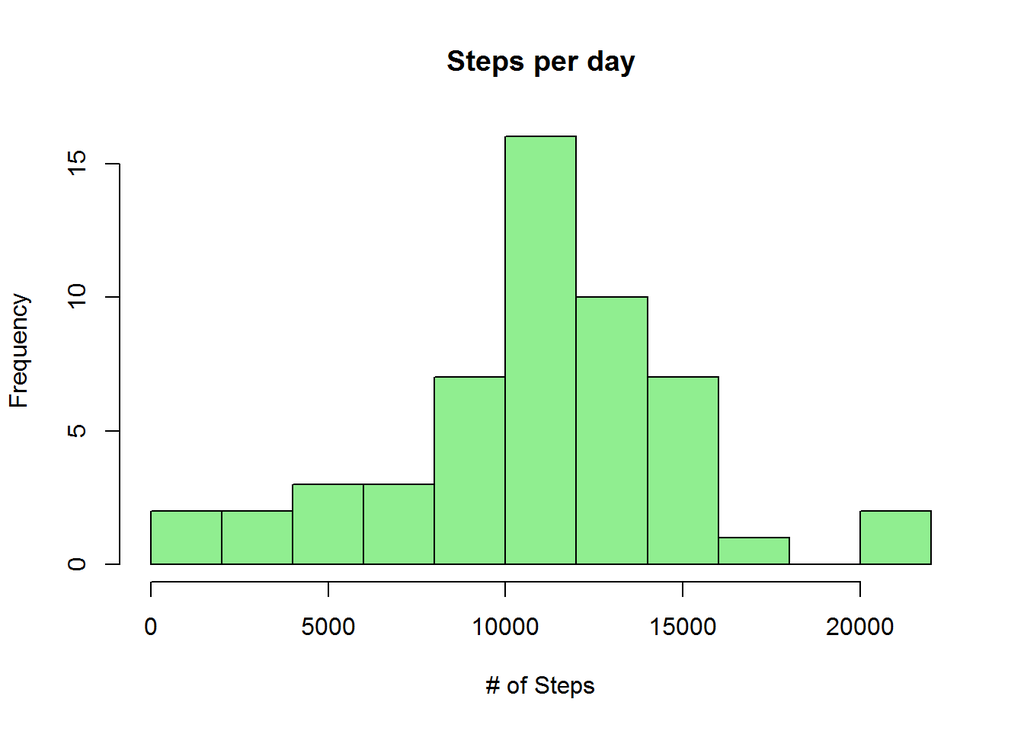

```r
hist(stepsPerDay$Steps, breaks = 8, xlab = "# of Steps", main = "Steps per day", col="lightgreen")
```

#### Mean and median number of steps taken each day

```r
mean(stepsPerDay$Steps)
```

```
## [1] 10766.19
```

```r
median(stepsPerDay$Steps)
```

```
## [1] 10765
```

### What is the average daily activity pattern?

#### Average the data from multiple days into 5 min intervals

```r
avgDailyAct <- tapply(activityNew$steps, activityNew$interval, mean)
str(avgDailyAct)
```

```
##  num [1:288(1d)] 1.717 0.3396 0.1321 0.1509 0.0755 ...
##  - attr(*, "dimnames")=List of 1
##   ..$ : chr [1:288] "0" "5" "10" "15" ...
```

#### Plotting the avg number of steps against 5 min intervals throughout the day

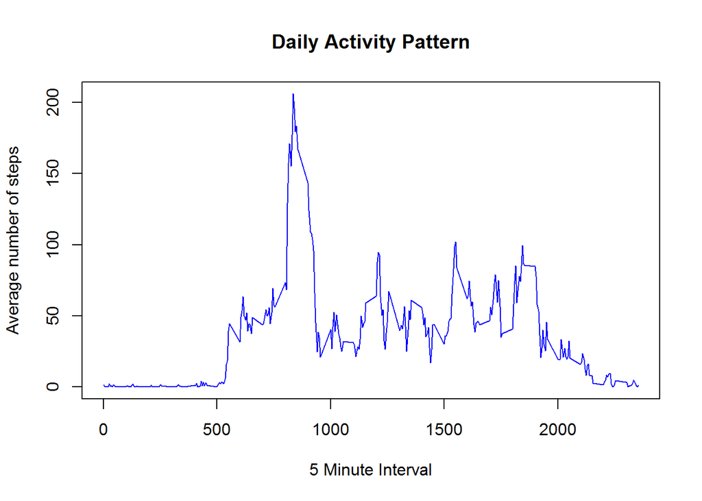

```r
plot(y = avgDailyAct, x = names(avgDailyAct), type = "l", xlab = "5 Minute Interval",
    main = "Daily Activity Pattern", ylab = "Average number of steps", col="blue")
```

#### Finding Which 5-minute interval, on average across all the days in the dataset, contains the maximum number of steps

```r
maxInterval <- avgDailyAct[avgDailyAct==max(avgDailyAct)]
```

#### Interval 835 had the maximum number of average steps taken - 206

### Imputing missing values

#### Finding total number of missing values

```r
sum(is.na(activityData$steps))
```

```
## [1] 2304
```

```r
activityApprox <- activityData
activityApprox[which(is.na(activityApprox$steps)),1] <-
                avgDailyAct[as.character(activityApprox[which(is.na(activityApprox$steps)),3])]
sum(is.na(activityApprox))
```

```
## [1] 0
```

#### The missing values have been filled with the approx values from the daily average values

#### Comparing pre and post approximated values via histogram for steps per day

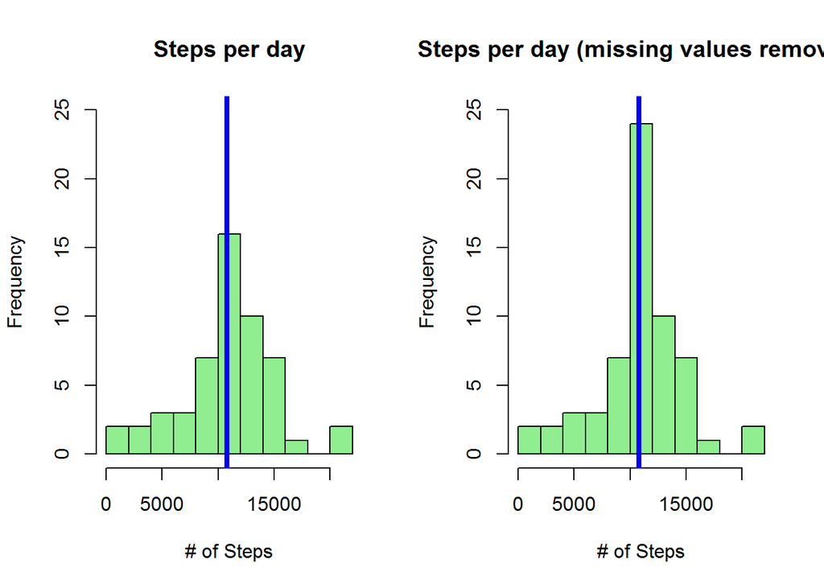

```r
approxStepsPerDay <- aggregate(activityApprox$steps ~ activityApprox$date, FUN=sum, )
colnames(approxStepsPerDay) <- c("Date","Steps")
par(mfrow=c(1,2))
hist(stepsPerDay$Steps, breaks = 8, xlab = "# of Steps", main = "Steps per day", col="lightgreen"
    , ylim=c(0,25))
abline(v = median(stepsPerDay$Steps), col = 4, lwd = 4)
hist(approxStepsPerDay$Steps, breaks = 8, xlab = "# of Steps", main = "Steps per day (missing values removed)", col="lightgreen"
     , ylim=c(0,25))
abline(v = median(approxStepsPerDay$Steps), col = 4, lwd = 4)
```

#### Calculating mean and median of dataset with missing values replaced

```r
mean(approxStepsPerDay$Steps)
```

```
## [1] 10766.19
```

```r
median(approxStepsPerDay$Steps)
```

```
## [1] 10766.19
```

#### Finding impact of replacing missing values

```r
mean(approxStepsPerDay$Steps) - mean(stepsPerDay$Steps)
```

```
## [1] 0
```

```r
median(approxStepsPerDay$Steps) - median(stepsPerDay$Steps)
```

```
## [1] 1.188679
```

#### There is no difference in the mean however the median shifted by 1.188679

### Comparing activity patterns between weekday and weekends

#### Using weekdays function to factor the dataset into weekdays and weekends

```r
activityApprox$date <- as.Date(activityApprox$date)
activityApprox$wkday <- weekdays(activityApprox$date)
activityApprox$fwkday <- as.factor(c("weekend","weekday"))
activityApprox[activityApprox$wkday == "Sunday" | activityApprox$wkday == "Saturday",5] <- factor("weekend")
activityApprox[!(activityApprox$wkday == "Sunday" | activityApprox$wkday == "Saturday"),5] <- factor("weekday")
```

#### Creating separate datasets for weekdays and weekends

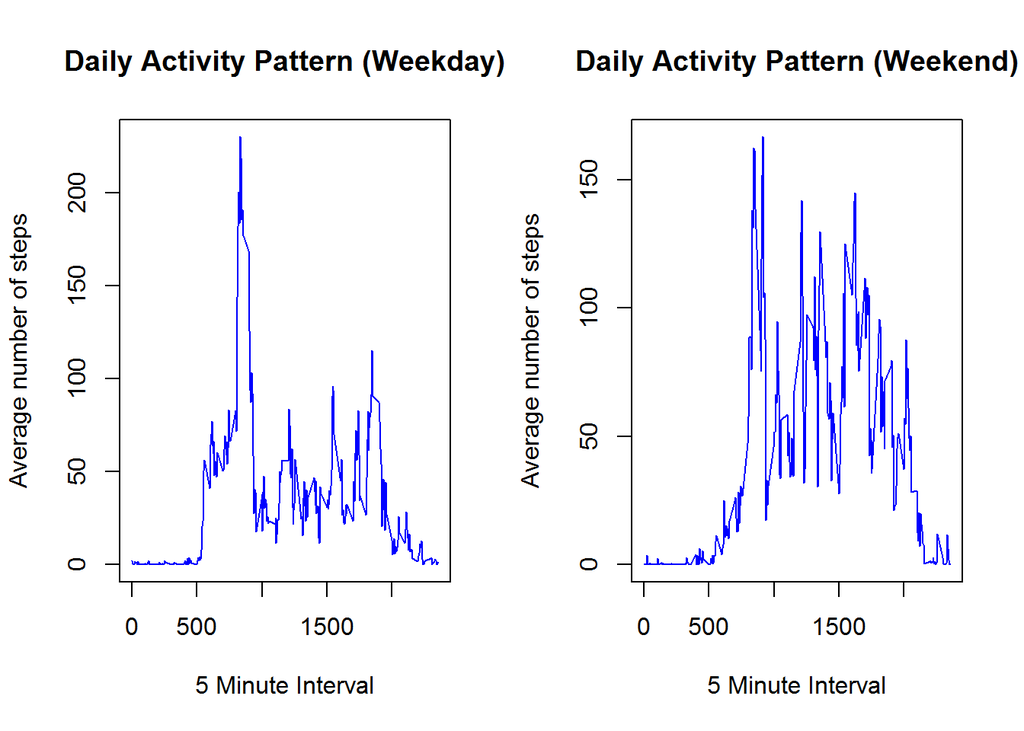

```r
activityWeekdays <- subset(activityApprox, fwkday == "weekday")
activityWeekends <- subset(activityApprox, fwkday == "weekend")
avgDailyAct_weekday <- tapply(activityWeekdays$steps, activityWeekdays$interval, mean)
avgDailyAct_weekend <- tapply(activityWeekends$steps, activityWeekends$interval, mean)
par(mfrow=c(1,2))
plot(y = avgDailyAct_weekday, x = names(avgDailyAct_weekday), type = "l"
    , xlab = "5 Minute Interval", main = "Daily Activity Pattern (Weekday)"
    , ylab = "Average number of steps", col="blue")
plot(y = avgDailyAct_weekend, x = names(avgDailyAct_weekend), type = "l"
    , xlab = "5 Minute Interval", main = "Daily Activity Pattern (Weekend)"
    , ylab = "Average number of steps", col="blue")
```

#### The activity trends are significantly different during weekdays and weekends.

#### During weekdays the average number of steps taken are very high towards the beginning of the day with considerably lower numbers for the rest of the day.

#### During weekends the average number of steps taken peak during the mornings however they stay high during the entire day with multiple mini peaks.